# Infection Dynamics with Aging

Galerkin Methods for Malaria Epidemiology

John M. Henry, David L. Smith

2023-01-24

`~/Human Ecology/Aging.Rmd`

```r
require(exDE)
require(knitr)
require(deSolve)
require(viridis)
require(rootSolve)
#source("Garki_Viz.R")
```

$\uparrow$ Library || Human Ecology

## Intro

Age plays an important role in malaria epidemiology – almost everything we want to count or estimate varies with age and exposure in human populations. When we first learned about the dynamics of malaria, using Ross’s model, we encountered the concept of a *steady state.* It’s a simple concept for a simple model – a good place to start – but we can’t make much headway if the models can’t deal with age. When it comes to age, we would call the Ross model inadequate – it lacks a basic feature that is an essential part of malaria epidemiology.

We need new models and new concepts to understand some of the age-related patterns we observe in malaria data. Perhaps we *could* think of a steady state as a point estimate that represents something like a population average weighted by age, or we *could* interpret that point estimate through the concept of a *sentinel* population that was defined by age (*e.g.* the *Pf*PR in older children). Either way, we would still need a way of developing and defining the concepts and metrics, and we would need algorithms to unpack the effects of age. We thus need model families, algorithms and computational methods that allow us to understand and evaluate malaria dynamics in cohorts as they age, so we can compare any algorithms we have developed against a gold standard. At the same time, we need to understand patterns in cross-sectional surveys where we stratify outcomes by age. In practice, we need a way of dealing with both age and time.

In malaria epidemiology, age plays a major role. First, people are born uninfected, so the prevalence of infection rises in cohorts as they age. Second, malaria immunity develops with age and exposure. There are also other effects of age. Death rates, hemoglobin and anemia, body mass, nutritional status, maternal protection, and other factors that affect malaria vary by age. What we observe is a combination of factors that wax or wane with age, exposure and immunity. Because of immunity (and perhaps other age-related factors), the risk of exposure, the risk of disease, parasite densities and detection, and infectiousness all change with age. To understand these processes, we would ideally examine patterns in individuals or cohorts with similar exposure histories. Since so much depends on the history of exposure, malaria immuno-epidemiology is best understood as ontogeny.

In developing our analyses, we would like to input exposure and drug taking by age and output malaria prevalence, malaria incidence, severe malaria incidence, and infectiousness by age. Mathematically, the steady state concept becomes something like a *stable orbit* – if we held exposure constant in a population, then we would understand the epidemiology by plotting the states in a cohort as it ages. This ends up being a trivial computational task. Since age and time proceed at the same rate, we can substitute *age* for *time.* We initiate the states for a birth cohort, and we solve the dynamical systems.

A reasonable starting point for understanding cohort dynamics is the Garki Model [1]. Here, we use the Garki Model to introduce two algorithms that we have implemented to stratify human populations by age. We show how to assess the accuracy of those algorithms.

In the following, the notation tends to follow the conventions established by Wu, *et al.* (2022) [2].

## Methods

### ${\mathscr X}(a,t)$

All of the *base model families* we develop in `exDE` to describe the dynamics of malaria infection and immunity in humans define a state space over age and time, $\mathscr X(a,t)$. In those models, functions accept the daily EIR as an argument, `eir`. Inside of the functions, the FoI is computed using the function `foi = F_foi(eir).` Here, we would like to remain focused on the problem of aging, so we have formulated the models with exogenous forcing by functions describing the FoI, $h$. We can think of any model family for the dynamical component defining human infections and immunity as a set of PDEs with the following form:

$$\frac{\partial {\mathscr
X(a,t)}}{\partial a} + \frac{\partial {\mathscr X(a,t)}}{\partial t} =
F_{\mathscr X}\left({\mathscr X}, h \right)$$

The boundary condition (*i.e.* the state of a birth cohort) could depend on the states. For example, we might want to consider maternal protection in newborns as a function of the immune status of their mothers:

$${\mathscr X}(0, t) = B_{\mathscr
X}({\mathscr X},t).$$

Solving equations over age and time is cumbersome, so many analyses simply ignore age, and focus on the temporal dynamics. We get solutions ${\mathscr X}(t|h)$ by solving:

$$\frac{\partial {\mathscr X(t)}}{d t} =
F_{\mathscr X}\left({\mathscr X(t)}, h \right)$$

To understand the patterns wrt age, we could ignore time and focus on dynamics of a cohort born on day, $d$. We redefine the FoI $h_d(a)$ defined such that $a + d = t$. We set initial conditions for a cohort, and we get solutions ${\mathscr X}(a|h)$ by solving:

$$\frac{d {\mathscr X\left(a\right)}}{d a}
= F_{\mathscr X}\left({\mathscr X(a)}, h \right)$$

**Computational Galerkin Methods**

We seek algorithms that allow us to approximate the full dynamics simultaneously dealing with age and time. The idea is to stratify the population into $n + 1$ discrete age classes by defining a mesh:

$$\left\{0, \ell_1, \ell_2, ..., \ell_n,
\infty\right\}$$

which defines a set of age classes, either:

- The youngest cohort ($i=1$), $a\in[0, \ell_1)$, or
- The oldest cohort ($i=n+1$), $[\ell_n, \infty)$, or
- for all the other cohorts ($i \in 2,\ldots n$), $a \in[\ell_{i-1}, \ell_i)$

For each age class, we have a set of state spaces:

$${\mathscr X}_i(t)$$
The dynamics within an age class are defined by $F_{\mathscr X}$, but they are linked by the aging operator, $\mathscr A$, such that:

$$\frac{\partial {\mathscr X_i(t)}}{d t} =
F_{\mathscr X}\left({\mathscr X(t)}, h \right) + {\mathscr A}
\left({\mathscr X}, \vec \ell\right)$$

$${\mathscr X_i}(h(t)) \approx
\int_{\ell_{i - 1}}^{\ell_i} {\mathscr X(a|h)}\; d a$$

The two algorithms we have implemented are called `boxcar` models, and `lagged aging.` These are part of a broader class of computational methods, called Galerkin methods [3].

### FoI

We want to deal with the FoI generically, as a function $h(t)$ that could take any form. Notably, if we know $h(t)$ for a population, then we could define the FoI for any cohort born on day $d$ at age $a = t-d$ by defining $h_d(a) = \omega(a) h(t-d)$, where $\omega(a)$ is an age weight. For consistency, the age weights must be constrained so that $h(t)$ is the weighted average, so:

$$\int_0^\infty \omega(a) H(a) da
=1$$

This constraint is built into the framework. Here, we want to focus on age and time, so we define some functions to look at seasonality, age, and generalized trends:

**Age**

Later, we will define parameters that assign a class to `par$A_foi` to dispatch the generic function `foiAge(t, par)`:

```r
foiAge = function(t, par){UseMethod("foiAge", par$A_foi)}
foiAge.0 = function(t, par){1}
foiAge.type2 = function(t, par){.0001 + 1.4*t/365/(4+t/365)}
```

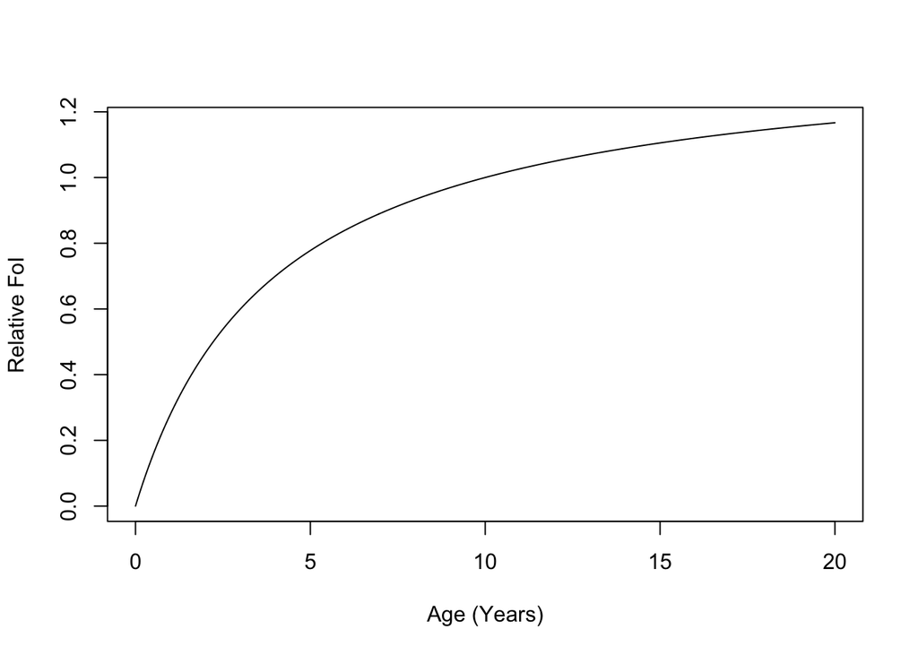

```r
par = list()
par$A_foi = "type2"
class(par$A_foi) <- "type2"
tt = seq(0, 20*365, by = 20)
plot(tt/365, foiAge(tt, par), type = "l", xlab = "Age (Years)", ylab = "Relative FoI")
```

**Seasonality**

Later, we will define parameters that assign a class to `par$S_foi` to dispatch the generic function `foiSeason(t, par)`: To implement the model, we first define some seasonal patterns.

```r
foiSeason = function(t, par){UseMethod("foiSeason", par$S_foi)}
foiSeason.0 = function(t, par){1}
foiSeason.sin = function(t, par){with(par,{1 + sin(2*pi*(t-shift)/365)})}
```

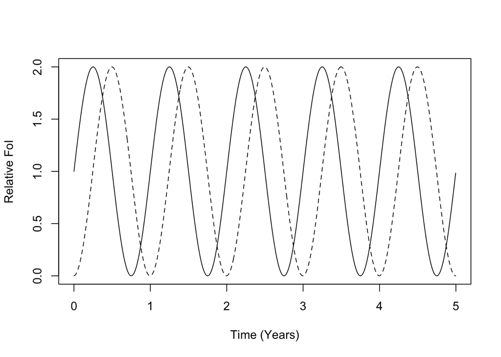

```r
tt = seq(0, 5*365, by = 2)
par$S_foi = "sin"
class(par$S_foi) <- "sin"
par$shift=0
plot(tt/365, foiSeason(tt, par), type = "l", xlab = "Time (Years)", ylab = "Relative FoI")
par$shift=90
lines(tt/365, foiSeason(tt, par), lty=2)
```

**Trend**

```r
foiTrend = function(t, par){UseMethod("foiTrend", par$T_foi)}
foiTrend.0 = function(t, par){1}
foiTrend.crazy = function(t, par){exp(-t/7300)*(1+sin(1+2*pi*t/730)*
                                                  sin(1+2*pi*t/5/365)*
                                                  sin(1+2*pi*t/13/365))}
```

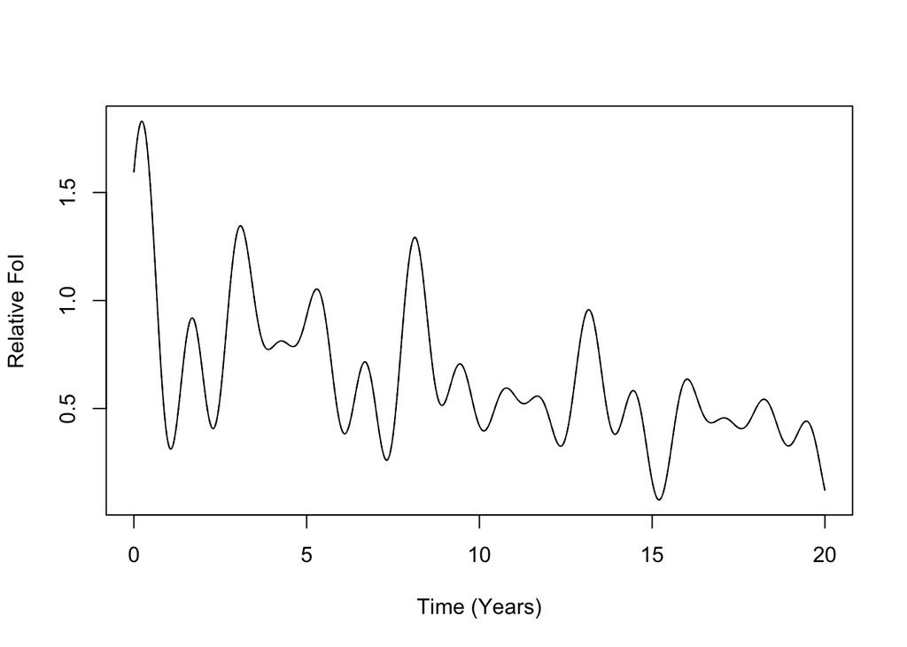

```r
tt = seq(0, 20*365, by = 5)
par$T_foi = "crazy"
class(par$T_foi) <- "crazy"
plot(tt/365, foiTrend(tt, par), type = "l", xlab = "Time (Years)", ylab = "Relative FoI")
par$shift=90
lines(tt/365, foiTrend(tt, par), lty=2)
```

Now, we can compare the histories of exposure for cohort born five years apart as they age, which are affected differently by the trend.

Exposure in the two cohorts differs by age over time (plotted for the first 20 years of life, for each cohort):

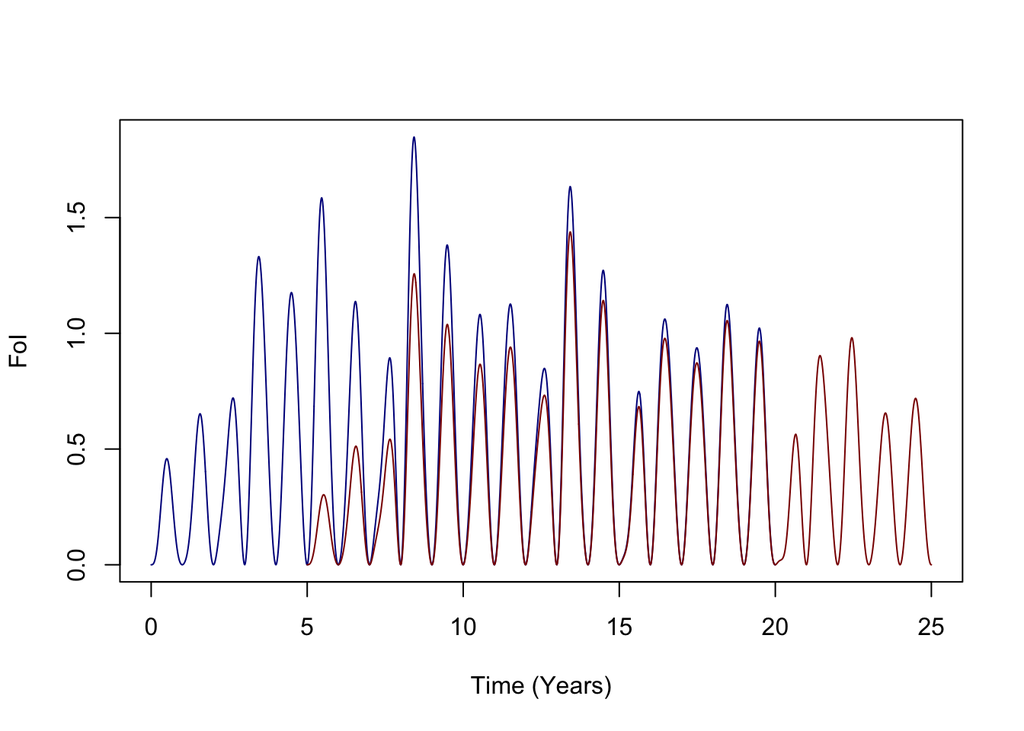

```r
gap = 5*365
plot(tt/365, foiAge(tt, par)*foiSeason(tt,par)*foiTrend(tt, par), type = "l", xlab = "Time (Years)", ylab = "FoI", xlim = c(0, 25), col = "darkblue")
lines(tt/365+ gap/365, foiAge(tt, par)*foiSeason(tt+gap,par)*foiTrend(tt+gap, par), col = "darkred")
```

And it differs by age:

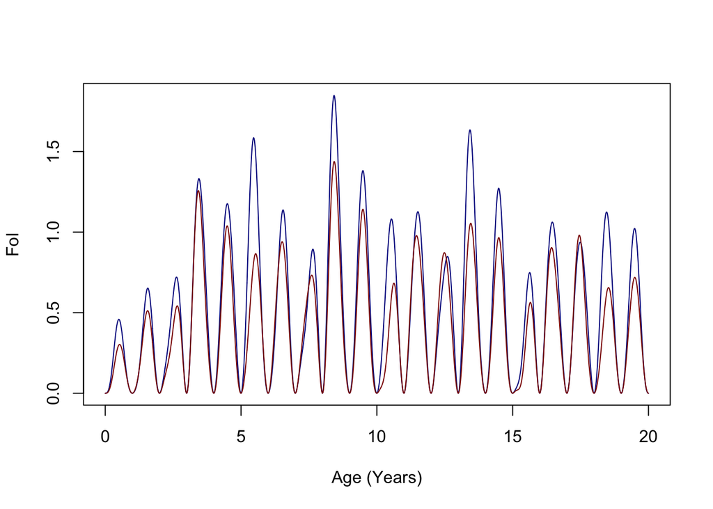

```r
gap = 5*365
plot(tt/365, foiAge(tt, par)*foiSeason(tt,par)*foiTrend(tt, par), type = "l", xlab = "Age (Years)", ylab = "FoI", col = "darkblue")
lines(tt/365, foiAge(tt, par)*foiSeason(tt+gap,par)*foiTrend(tt+gap, par), col = "darkred")
```

And cumulative exposure differs by age:

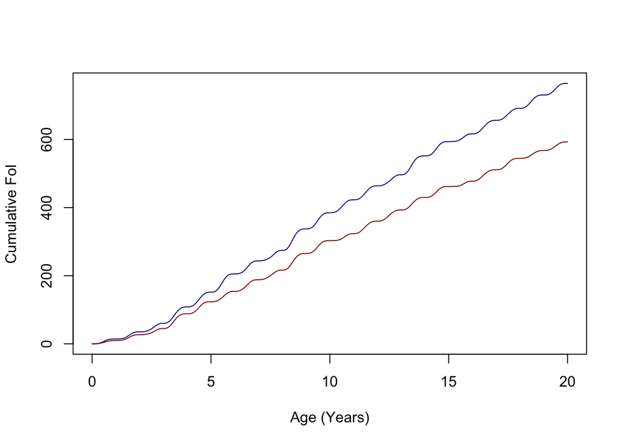

```r
plot(tt/365, cumsum(foiAge(tt, par)*foiSeason(tt,par)*foiTrend(tt, par)), type = "l", xlab = "Age (Years)", ylab = "Cumulative FoI", col = "darkblue")
lines(tt/365, cumsum(foiAge(tt, par)*foiSeason(tt+gap,par)*foiTrend(tt+gap, par)), col = "darkred")
```

These functions thus allow us to pressure test our models.

### Boxcar

In boxcar models, we sub-divide the human population by defining an even mesh on age, and we connect these models by defining the aging process as a constant *flux* of individuals from one age class to the next by states. In a diagram, these state spaces look like box cars on a train. For example, if we define a mesh by an interval $D$, then we would get a set of strata, and the dynamics of infection in these strata would look like the following. For the youngest age class, we implement the boundary condition:

$$\frac{\partial {\mathscr X_1(t)}}{d t} =
F_{\mathscr X}\left({\mathscr X}_1, h \right) + B(t) - \frac{1}{D}
X_1(t)$$

and for all the other classes:

$$\frac{\partial {\mathscr X_i(t)}}{d t} =
F_{\mathscr X}\left({\mathscr X}_i, h \right) + \frac{1}{D} \left(
{\mathscr X}_{i - 1} - X_{i} \right)$$

The $i^{th}$ stratum is meant to represent the *average* for a cohort aged
$$a \in [iD-D, iD).$$
The *average* age of each stratum will tend to be close to the mid point of the interval, or $iD - D/2$.

In the limit as $D$ becomes small, the stratified population converge to exact solutions to

$$\frac{\partial {\mathscr
X(a,t)}}{\partial a} + \frac{\partial {\mathscr X(a,t)}}{\partial t} =
F_{\mathscr X}\left({\mathscr X}, h \right).$$

This is, in fact, a starting point for understanding numerical solutions to these systems of PDEs, but solving these equations can be quite demanding.

We are interested in approximate solutions for values of $D$ that make sense epidemiologically, but that are not as computationally demanding.

### Uneven Boxcar

In uneven boxcar models, we sub-divide the human population by defining an arbitrary mesh on age, defined by a set of lags, $\left\{\ell\right\}$. The idea is to reduce the computational load by lumping age classes that are similar, and since most things change faster earlier in life, the mesh will be finer in children and coarser in adults. As before, we connect these models by defining the aging process as a constant *flux* of individuals from one age class to the next by states.

$$\frac{\partial {\mathscr X_1(t)}}{d t} =
F_{\mathscr X}\left({\mathscr X}_1, h \right) + B(t) - \frac{1}{\ell_1}
X_1(t)$$

and for all the other classes:

$$\frac{\partial {\mathscr X_i(t)}}{d t} =
F_{\mathscr X}\left({\mathscr X}_i, h \right) - \frac{X_{i}}{\ell_i} +
\frac{{\mathscr X}_{i - 1}}{\ell_{i-1}}$$

The $i^{th}$ stratum is meant to represent the *average* for a cohort aged
$$a \in \left[\sum_{j<i} \ell_{j}, \sum_{j\leq
i} \ell_{j}\right].$$
The *average* age of each stratum will tend to be close to the mid point of each interval. If we pick the mesh well, the state variables will work just fine.

In the limit as $D$ becomes small, the stratified population converge to exact solutions to

$$\frac{\partial {\mathscr
X(a,t)}}{\partial a} + \frac{\partial {\mathscr X(a,t)}}{\partial t} =
F_{\mathscr X}\left({\mathscr X}, h \right).$$

This is, in fact, a starting point for understanding numerical solutions to these systems of PDEs, but solving these equations can be quite demanding.

We are interested in approximate solutions for values of $D$ that make sense epidemiologically, but that are not as computationally demanding.

### Lagged Aging

We would like to explore the possibility of putting a coarser mesh on age and approximating the dynamics with a system of delay differential equations. We define a (possibly uneven) mesh on age:

$${0, \ell_1, \ell_2, ...,
\ell_n}$$

We will need to worry about the variables in ${\mathscr x}_i$ which we refer to using two indices:
$${\mathscr X}_i = \left\{
x_{i,1}, x_{i,2}, ..., x_{i,j}, ...\right\}$$
and we let
$$X_i = \sum_i x_{i,j}$$
denote the total size of the $i^{th}$ age class.

We let $\mu$ denote the death rate (we assume a constant, per - capita death rate for everyone all at once, for the moment), and $B$ the population birth rate, and $B_j(t)$ the birth rate into $X_{1,j}$ at time $t$. For the first age class, the change in density for each variable is:

$$\frac{d x_{1,j}}{dt} =
F_j\left({\mathscr X}_1, h \right) +
B_j(t) - \frac{x_{1,j}}{X_1}\sum_j B_j (t - \ell_1) e^{ - \mu_1
\ell_1}$$

and for $i>1$:

$$\frac{d x_{i,j}}{dt} = F_j
\left({\mathscr X}_i, h \right) +
e^{-\mu_{i-1} \ell_{i-1}} \frac{x_{i-1,j}}{X_{i-1}}
X_{i-1}(t-\ell_{i-1}) -
\frac{x_{i,j}}{X_i} X_i (t-\ell_i) e^{ - \mu_i \ell_i}$$

## The Garki Model

### Eqs.

#### -

A mathematical model was developed to support a large-scale malaria trial called the Garki Project [1]. The model marked a radical departure from the Ross-Macdonald model. The basic idea was to sub-divide a population by immunity into two classes: non-immune and partially immune. Infection dynamics would be tracked within each immune class, and a fraction of infected individuals would acquire immunity. Dietz, following up on some work done by Bailey, reformulated Macdonald’s model for superinfection, so that clearance rates would depend on exposure: if $h$ were the FoI and $r_i$ was the clearance rate (for infections in each immune class), then:

$$R_i(h) = \frac{h}{e^{h/r_i} -
1}$$

Here, we have modified the the Garki Model in several ways:

The dynamics are:

$$\begin{equation}
\begin{array}{rl}
\frac{\textstyle{\partial x_1(a,t)}}{\textstyle{\partial a}} +
\frac{\textstyle{\partial x_1(a,t)}}{\textstyle{\partial t}} &= - h
x_1 + R_1(h)\; y_2 - \mu x_1 \\
\frac{\textstyle{\partial x_2(a,t)}}{\textstyle{\partial a}} +
\frac{\textstyle{\partial x_2(a,t)}}{\textstyle{\partial t}} &= h
x_1 - \nu x_2 - \mu x_2\\
\frac{\textstyle{\partial y_1(a,t)}}{\textstyle{\partial a}} +
\frac{\textstyle{\partial y_1(a,t)}}{\textstyle{\partial t}} &= \nu
x_2 - \alpha_1 y_1 - \mu y_1 \\
\frac{\textstyle{\partial y_2(a,t)}}{\textstyle{\partial a}} +
\frac{\textstyle{\partial y_2(a,t)}}{\textstyle{\partial t}} &=
\alpha_1 y_1 - R_1(h)\; y_2 - \alpha_2 y_2 - \mu y_2\\
\frac{\textstyle{\partial y_3(a,t)}}{\textstyle{\partial a}} +
\frac{\textstyle{\partial y_3(a,t)}}{\textstyle{\partial t}} &=
\alpha_2 y_2 + \nu x_4 - R_2(h)\; y_3 - \mu y_3\\
\frac{\textstyle{\partial x_3(a,t)}}{\textstyle{\partial a}} +
\frac{\textstyle{\partial x_3(a,t)}}{\textstyle{\partial t}} &=
R_2(h)\; y_3 - h x_3 - \mu x_3\\
\frac{\textstyle{\partial x_4(a,t)}}{\textstyle{\partial a}} +
\frac{\textstyle{\partial x_4(a,t)}}{\textstyle{\partial t}} &= h
x_3 - \nu x_4 - \mu x_4\\
\end{array}
\end{equation}$$

with the boundary condition $x_1(0, t) = \delta(t).$

#### Solutions

```r
delta = function(t, par){UseMethod("delta", par$B_f)}
delta.0 = function(t, par){par$B}
delta.exp = function(t, par){par$B*exp(t/7300)}
```

When we write out the equations, we’ll be careful to pass and return the variables in the same order they appear in these equations, and we define a vector of variable names:

```r
varNames_Garki <- c("x1", "x2", "y1", "y2", "y3", "x3", "x4")
```

We will often want to transform these variables into meaningful quantities:

- The *total* population density: $x_1+x_2+y_1+y_2+y_3+x_3+x_4$
- *non-Immune* population density: $x_1+x_2+y_1+y_2$
- *semi-Immune* population density: $y_3+x_3+x_4$
- *infected* population density:
- *true prevalence*
- Infect prevalence among semi-immune
- Infection prevalence among semi-immune

```r
summaryOutputs_Garki = function(out, params){with(c(out,params),{
  total = x1+x2+x3+x4+y1+y2+y3
  nonImmune = x1+x2+y1+y2
  semiImmune = y3+x3+x4
  infected = y1+y2+y3+x2+x4
  latent = (x2+x4)/total
  truePR = infected/total
  prImmune = q3*y3/semiImmune
  prNonImmune = (q1*y1+q2*y2)/nonImmune
  PR = c(q1*y1+q2*y2+q3*y3)/total
  out$total=total
  out$nonImmune=nonImmune
  out$semiImmune=semiImmune
  out$infected=infected
  out$latent=latent
  out$truePR = truePR
  out$prImmune = prImmune
  out$prNonImmune= prNonImmune
  out$PR = PR
  return(out)
})}
```

This function makes a parameter set to simulate the dynamics. The default values are from Table 2 in [1]. To dispatch the generic functions `foiSeason` and `foiAge`, we pass the suffix as a text string. The function sets things up, so we don’t have to think about it, and returns the parameters as a `list`:

```r
makePar_Garki = function(r1=.0023, r2=.023, nu=1/15, alpha1=.002, alpha2=.00019,
                         q1=.95, q2=0.8, q3=0.5,
                         H=1, mu=.0365/365, d=0,
                         S_foi = "0", A_foi="0", T_foi = "0", B_f="0"){
 par = list()
 class(par) <- S_foi
 par$B = mu*H
 par$r1=r1
 par$r2=r2
 par$nu=nu
 par$alpha1=alpha1
 par$alpha2=alpha2
 par$mu=mu
 par$q1=q1
 par$q2=q2
 par$q3=q3
 par$S_foi = S_foi
 class(par$S_foi) = S_foi
 par$A_foi = A_foi
 class(par$A_foi) = A_foi
 par$T_foi = T_foi
 class(par$T_foi) = T_foi
 par$B_f = B_f
 class(par$B_f) = B_f
 par$d=d
 par$shift=d
 return(par)
}
```

```r
Garki_dXdt = function(t, y, params){with(c(params, as.list(y)),{
 h = foi*foiSeason(t, params)*foiAge(t, params)*foiTrend(t, params)
 R1 = h/(exp(h/r1) - 1)
 R2 = h/(exp(h/r2) - 1)

 dx1 = delta(t, params) - h*x1 + R1*y2 - mu*x1
 dx2 = h*x1 - nu*x2 - mu*x2
 dy1 = nu*x2 - alpha1*y1 - mu*y1
 dy2 = alpha1*y1 - R1*y2 - alpha2*y2 - mu*y2
 dy3 = alpha2*y2 + nu*x4 - R2*y3 - mu*y3
 dx3 = R2*y3 - h*x3 - mu*x3
 dx4 = h*x3 - nu*x4 - mu*x4

 list(c(dx1, dx2, dy1, dy2, dy3, dx3, dx4))
})}
```

```r
timeSolve_Garki = function(foi, params=makePar_Garki(), Tmax=20, tmesh=30){
 tt = seq(round(tmesh/2), Tmax*365, by=tmesh)
 params$foi = foi
 params$B = 0
 y0 = with(params, c(x1=1, x2=0, y1=0, y2=0, y3=0, x3=0, x4=0))
 out = data.frame(lsode(y0,tt,Garki_dXdt,params))
 class(out) = "dynamics"
 out$time = tt
 return(summaryOutputs_Garki(out, params))
}
```

```r
out_time = timeSolve_Garki(6/365)
```

#### Plotting

We set up functions to plot the outputs from various wrappers:

```r
plotGarkiVars = function(out, norm=FALSE, ...){
  UseMethod("plotGarkiVars", out)
}

pointsGarkiVars = function(out, norm=FALSE, ppch=1){
  UseMethod("pointsGarkiVars", out)
}
```

```r
lines_Garki = function(tt, out, clrs=NULL, ltype="l", ltty=1, norm=FALSE){with(out,{
  if(norm==FALSE) fac = 1
  if(norm==TRUE) fac = 1/total
  if(is.null(clrs)) clrs = turbo(7)
  lines(tt, fac*x1, col=clrs[1], lty=ltty, type=ltype)
  lines(tt, fac*x2, col=clrs[2], lty=ltty, type=ltype)
  lines(tt, fac*x3, col=clrs[3], lty=ltty, type=ltype)
  lines(tt, fac*x4, col=clrs[4], lty=ltty, type=ltype)
  lines(tt, fac*y1, col=clrs[5], lty=ltty, type=ltype)
  lines(tt, fac*y2, col=clrs[6], lty=ltty, type=ltype)
  lines(tt, fac*y3, col=clrs[7], lty=ltty, type=ltype)
})}
```

```r
steps_Garki = function(tt, out, clrs=NULL, ltty, norm=FALSE){
  lines_Garki(tt, out, clrs, "s", ltty, norm)
}
```

```r
points_Garki = function(tt, out, norm=FALSE, ppch=1){with(out,{
  clrs = turbo(7)
  if(norm==FALSE) fac = 1
  if(norm==TRUE) fac = 1/total
  if(is.null(clrs)) clrs = turbo(7)
  points(tt, fac*x1, col=clrs[1], pch=ppch)
  points(tt, fac*x2, col=clrs[2], pch=ppch)
  points(tt, fac*x3, col=clrs[3], pch=ppch)
  points(tt, fac*x4, col=clrs[4], pch=ppch)
  points(tt, fac*y1, col=clrs[5], pch=ppch)
  points(tt, fac*y2, col=clrs[6], pch=ppch)
  points(tt, fac*y3, col=clrs[7], pch=ppch)
})}
```

```r
labels_Garki = function(ty, out, MX, clrs=NULL, ccx=1, norm=FALSE){with(out,{
  ixX = which(ty<MX)
  if(norm==FALSE) fac=1
  if(norm==TRUE) fac=1/total[ixX]
  if(is.null(clrs)) clrs = turbo(7)
  fac1 = 1.03
  ix = which.max(y1[ixX]*fac)
  text(ty[ix], y1[ix]*fac[ix]*fac1, expression(y[1]), pos=4, col = clrs[5], cex=ccx)

  ix = which.max(y2[ixX]*fac)
  text(ty[ix], y2[ix]*fac[ix]*fac1, expression(y[2]), pos=3, col = clrs[6], cex=ccx)

  ix = which.max(x2[ixX]*fac)
  text(ty[7], x2[ix]/fac[ix]/2, expression(x[2]), pos=4, col = clrs[2], cex=ccx)

  fac2=1.02
  ix = round(length(y3[ixX])/3)
  text(ty[ix], y3[ix]*fac[ix]*fac2, expression(y[3]), pos=3, col = clrs[7], cex=ccx)

  ix = round(2*length(x3[ixX])/3)
  text(ty[ix], x3[ix]*fac[ix]/fac2, expression(x[3]), pos=1, col = clrs[3], cex=ccx)

  ix = length(x4[ixX])
  text(ty[ix], x4[ix]*fac[ix], expression(x[4]), pos=3, col = clrs[4], cex=ccx)

  ix = 1
  text(ty[ix+1], .95, expression(x[1]), pos=4, col = clrs[1], cex=ccx)
})}
```

#### Demo

```r
plotGarkiVars.dynamics = function(out, norm=FALSE, ccx=1, ltty=1, Tmax=NULL, newplot=TRUE){with(out,{
  clrs = turbo(7)
  ty = time/365
  if(is.null(Tmax)) Tmax=max(ty)
  if(newplot == TRUE){
    plot(ty, x1, type = "n", col = clrs[1],
        ylim = range(0, max(total)), xlim = c(0, Tmax),
        xlab = "Time (in Years)", ylab = "Density")
  labels_Garki(ty, out, Tmax, clrs, ccx, norm)
  }
  lines_Garki(ty, out, clrs, "l", ltty, norm)
})}

pointsGarkiVars.dynamics = function(out, norm=FALSE, ppch=15){
  ty = out$time/365
  points_Garki(ty, out, norm, ppch)
}
```

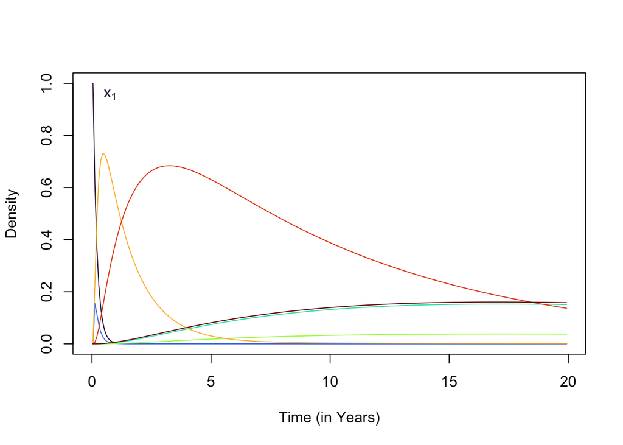

```r
plotGarkiVars(out_time)
```

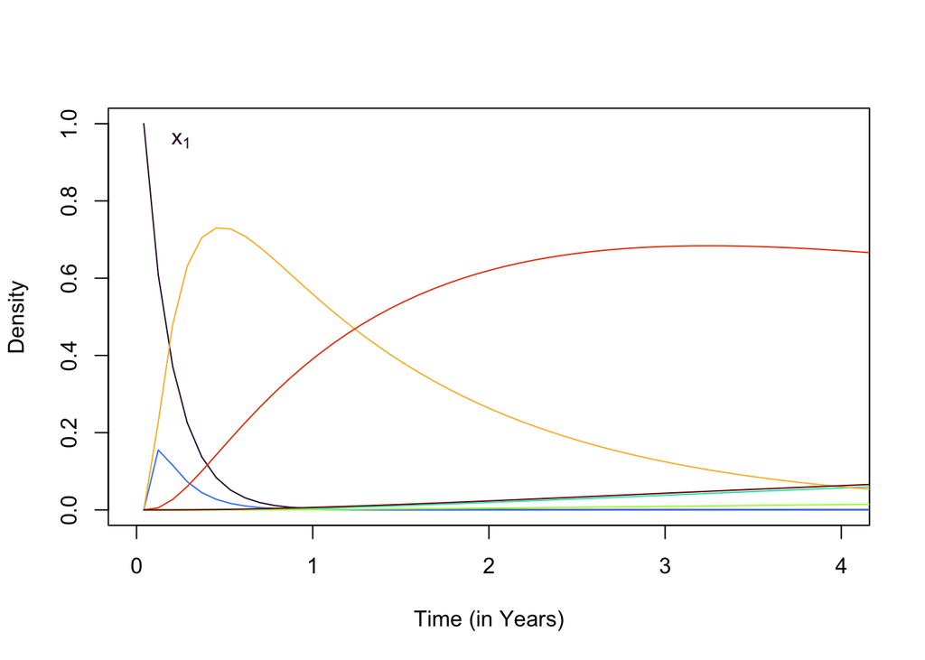

```r
plotGarkiVars(out_time, Tmax=4)
```

### Cohorts

#### -

By age, we get these equations:

$$\begin{equation}
\begin{array}{rl}
\frac{\textstyle{d x_1}}{\textstyle{d a}} &= - h x_1 + R_1(h)\; y_2
- \mu x_1 \\
\frac{\textstyle{d x_2}}{\textstyle{d a}} &= h x_1 - \nu x_2 - \mu
x_2\\
\frac{\textstyle{d y_1}}{\textstyle{d a}} &= \nu x_2 - \alpha_1 y_1
- \mu y_1 \\
\frac{\textstyle{d y_2}}{\textstyle{d a}} &= \alpha_1 y_1 -
R_1(h)\; y_2 - \alpha_2 y_2 - \mu y_2\\
\frac{\textstyle{d y_3}}{\textstyle{d a}} &= \alpha_2 y_2 + \nu x_4
- R_2(h)\; y_3 - \mu y_3\\
\frac{\textstyle{d x_3}}{\textstyle{d a}} &= R_2(h)\; y_3 - h x_3 -
\mu x_3\\
\frac{\textstyle{d x_4}}{\textstyle{d a}} &= h x_3 - \nu x_4 - \mu
x_4\\
\end{array}
\end{equation}$$

The initial conditions define some cohort that we want to follow, usually a birth cohort. To solve these equations, we write a function that computes the derivatives:

```r
Garki_dXda = function(t, y, params){with(c(params, as.list(y)),{
 h = foi*foiSeason(t, params)*foiAge(t, params)*foiTrend(t, params)
 R1 = h/(exp(h/r1) - 1)
 R2 = h/(exp(h/r2) - 1)

 dx1 = - h*x1 + R1*y2 - mu*x1
 dx2 = h*x1 - nu*x2 - mu*x2
 dy1 = nu*x2 - alpha1*y1 - mu*y1
 dy2 = alpha1*y1 - R1*y2 - alpha2*y2 - mu*y2
 dy3 = alpha2*y2 + nu*x4 - R2*y3 - mu*y3
 dx3 = R2*y3 - h*x3 - mu*x3
 dx4 = h*x3 - nu*x4 - mu*x4

 list(c(dx1, dx2, dy1, dy2, dy3, dx3, dx4))
})}
```

#### Wrapper

The following is a wrapper around `lsode` that accepts an average daily FoI (called `foi`), a parameter set, a maximum age `Amax` (in years), and a mesh size `tmesh` (in days). We initialize a cohort – all individuals are non-immune and uninfected (*i.e*, in state $x_1$). The size of the cohort is arbitrary, so we initialize it to $1$, and we can then interpret the orbits as the proportion of an original cohort:

```r
ageSolve_Garki = function(foi, params=makePar_Garki(), Amax=20, tmesh=10){
 age = seq(0, Amax*365, by=tmesh)
 params$foi = foi
 y0 = with(params, c(x1=1, x2=0, y1=0, y2=0, y3=0, x3=0, x4=0))
 out = data.frame(lsode(y0,age,Garki_dXda,params))
 class(out) = "cohort"
 out$age = age
 return(summaryOutputs_Garki(out, params))
}
```

```r
out_age = ageSolve_Garki(6/365, Amax=40)
```

#### Graphs

```r
plotGarkiVars.cohort = function(out, norm=FALSE, ltty=1, ccx=1, Amax=NULL, newplot=TRUE){with(out,{
  clrs = turbo(7)
  ty = age/365
  if(is.null(Amax)) Amax = max(ty)
  if(newplot == TRUE){
    plot(ty, x1, type = "n",
         ylim=range(0, max(total)), xlim=c(0, Amax), col = clrs[1],
         xlab = "Age (in Years)", ylab = "Density")
    labels_Garki(ty, out, Amax, clrs, ccx, norm)
  }
  lines_Garki(ty, out, clrs, "l", ltty, norm)
})}

pointsGarkiVars.cohort = function(out, norm=FALSE, ppch=15){
  ty = out$age/365
  points_Garki(ty, out, norm, ppch)
}
```

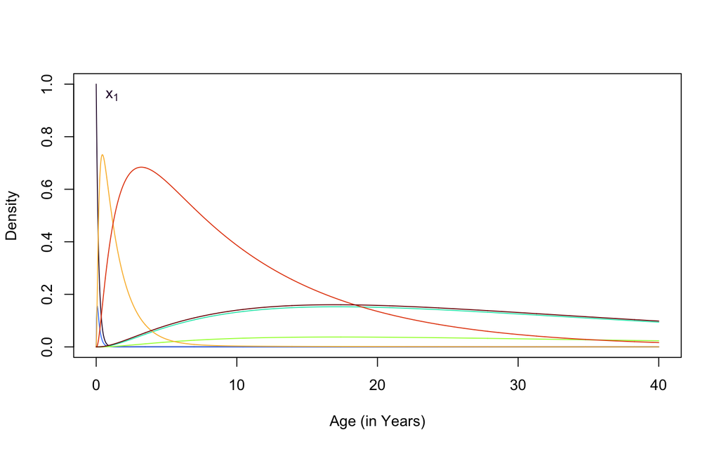

```r
plotGarkiVars(out_age)
```

We can replot this to focus on events early in life:

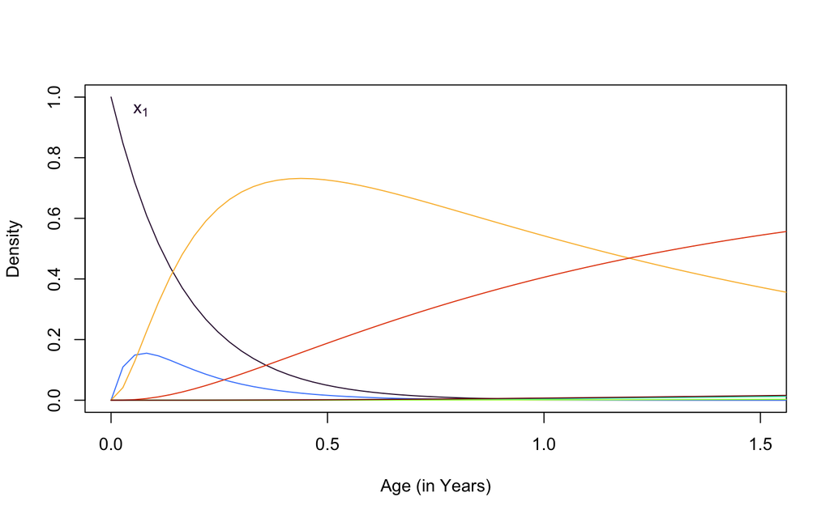

```r
plotGarkiVars(out_age, Amax=1.5)
```

### Boxcar

#### -

To formulate a boxcar model, we stratify our population into sub-groups by age. The dynamics within each age stratum follow the Garki model for the most part, but we also define an aging matrix ${\mathscr A}$ that defines a flux among age strata. Given a mesh of length $D$, the matrix is defined by a flux, $\lambda = 1/D$, and a maximum age $ND$:

$$\begin{equation}
{\mathscr A} = \left[
\begin{array}{cccccc}
-\lambda & 0 & 0 & \ldots & 0 & 0 \\
\lambda & -\lambda & 0 & \ldots & 0 & 0 \\
0 & \lambda & -\lambda & \ldots & 0 & 0 \\
\vdots & \vdots & \vdots & \ddots & \vdots &
\vdots\\
0 & 0 & 0 & \ldots & -\lambda & 0 \\
0 & 0 & 0 & \ldots & \lambda & 0 \\
\end{array} \right]
\end{equation}$$

Notably, the $N,N^{th}$ element of $\mathscr A$ is set equal to zero: we are lumping together everyone who is older than $DN$ days, so the last column has no flux out. Notably, columns of the matrix $\mathscr A$ sum to $0$ – we can think of it as an operator that conserves total density.

The aging transfer matrix ${\mathscr A}$ is constructed by a function

```r
AgingMatrix = function(D, N){
 M = N-1
 Aging = diag(-1/D, N)
 Aging[N,N] = 0
 Aging[cbind(1+1:M, 1:M)] = 1/D
 return(Aging)
}
```

To write out the equations, we must define the birth rate $B$ as a vector of length $N$ with $B_1=\delta(t)$ and $B_{i>0}=0$. The parameters here do not vary by age, but they *could* be vectors, and the variables are now vectors. The equations look the same, because we are abusing notation. The main difference is that we must multiply each variable by the aging transfer matrix:

$$\begin{equation}
\begin{array}{rl}
\frac{\textstyle{d x_{1}}}{\textstyle{dt}} &= B - h x_{1} +
R_{1}(h)\; y_{2} - \mu x_{1} + {\mathscr A} \cdot x_{1} \\
\frac{\textstyle{d x_{2}}}{\textstyle{dt}} &= h x_{1} - \nu x_{2} -
\mu x_{2}+ {\mathscr A} \cdot x_{2} \\
\frac{\textstyle{d y_{1}}}{\textstyle{dt}} &= \nu x_{2} -
\alpha_{1} y_{1} - \mu y_{1}+ {\mathscr A} \cdot y_{1} \\
\frac{\textstyle{d y_{2}}}{\textstyle{dt}} &= \alpha_{1} y_{1} -
R_{1}(h)\; y_{2} - \alpha_{2} y_{2} - \mu y_{2}+ {\mathscr A} \cdot
y_{2}\\
\frac{\textstyle{d y_{3}}}{\textstyle{dt}} &= \alpha_{2} y_{2} +
\nu x_{4} - R_{2}(h)\; y_{3} - \mu y_{3}+ {\mathscr A} \cdot y_{3}\\
\frac{\textstyle{d x_{3}}}{\textstyle{dt}} &= R_{2}(h)\; y_{3} - h
x_{3} - \mu x_{3}+ {\mathscr A} \cdot x_{3}\\
\frac{\textstyle{d x_{4}}}{\textstyle{dt}} &= h x_{3} - \nu x_{4} -
\mu x_{4}+ {\mathscr A} \cdot x_{4}\\
\end{array}
\end{equation}$$

The trick of naming the initial conditions vector no longer works, so we must extract the variables by name from the vector of all variables `y`:

```r
Garki_dXdt_boxcar = function(t, y, params, Aging){with(params,{
 x1 = y[1:N]; x2 = y[N + 1:N]; x3 = y[5*N + 1:N]; x4 = y[6*N + 1:N]
 y1 = y[2*N + 1:N]; y2 = y[3*N + 1:N]; y3 = y[4*N + 1:N];

 h = foi*foiSeason(t, params)*foiAge(t, params)*foiTrend(t, params)
 R1 = h/(exp(h/r1) - 1)
 R2 = h/(exp(h/r2) - 1)
 dx1 = births*delta(t, params) - h*x1 + R1*y2 - mu*x1 + Aging %*% x1
 dx2 = h*x1 - nu*x2 - mu*x2 + Aging %*% x2
 dy1 = nu*x2 - alpha1*y1 - mu*y1 + Aging %*% y1
 dy2 = alpha1*y1 - R1*y2 - alpha2*y2 - mu*y2 + Aging %*% y2
 dy3 = alpha2*y2 + nu*x4 - R2*y3 - mu*y3 + Aging %*% y3
 dx3 = R2*y3 - h*x3 - mu*x3 + Aging %*% x3
 dx4 = h*x3 - nu*x4 - mu*x4 + Aging %*% x4

 list(c(dx1, dx2, dy1, dy2, dy3, dx3, dx4))
})}
```

#### Wrapper

This solves the full set of equations for all the variables over time. We create the `births` vector $c(1, 0, 0, \ldots, 0)$ to ensure that births occur only in $x_{1,1}$.

```r
boxcarSolve_Garki = function(foi, params=makePar_Garki(), D=30, Amax=20){
 tt = seq(0, Amax*365, by=D)
 Dn = round(max(tt)/D)
 params$foi = foi
 params$Dn = Dn
 params$D = D
 params$births = c(1, rep(0, Dn-1))
 y0 = rep(0, 7*Dn)
 y0[1] = with(params, B/mu)
 params$B = c(B, rep(0, Dn-1))
 out = lsode(y0, tt, Garki_dXdt_boxcar, params, Aging=AgingMatrix(D, Dn))
}
```

This returns the steady states:

```r
tail2vars = function(out, par){with(par,{
  de2vars(tail(out,1)[-1], par)
})}
```

```r
de2vars = function(out, par){
   out1 = with(par,data.frame(matrix(out, nrow=N, ncol=7, dimnames = list(c(1:N), varNames_Garki))))
   return(summaryOutputs_Garki(out1, par))
}
```

```r
boxcarSteady_Garki = function(foi, params=makePar_Garki(), D=30, Amax=20){
 params$foi = foi
 Dn = round(Amax*365/D)
 N = Dn+1
 params$Dn = Dn
 params$N = N
 params$D = D
 params$births = c(1, rep(0,Dn))
 y0 = rep(.1, 7*N)
 Aging = AgingMatrix(D,N)
 out <- steady(y0,NULL,Garki_dXdt_boxcar, params, Aging=Aging)$y
 out = de2vars(out, params)
 params$age_mesh = c(1:Dn)*D
 out$min_age = c(0:Dn)*D
 out$max_age = c(c(1:Dn)*D, 36500)
 fullOutput = list(steady=out, par=params)
 class(fullOutput) <- "boxcar"
 return(fullOutput)
}
```

#### Graphs

```r
plotGarkiVars.boxcar = function(out, norm=FALSE, ltty=1, ccx=1, Amax=NULL, newplot=TRUE){with(out$steady,{
  clrs = turbo(7)
  #ty = (min_age + max_age)/2/365
  ty = min_age/365
  if(is.null(Amax)) Amax=max(ty)
  ix = which(ty<Amax)
  if(norm == FALSE) rng = range(0, total[ix])
  if(norm == TRUE) rng = with(out, range(0, x1/total, y1/total, x2/total, y2/total, x3/total, y3/total, x4/total))
  if(newplot == TRUE){
    plot(ty[ix], x1[ix], type = "n", col = clrs[1],
        ylim = rng, xlim = c(0, Amax),
        xlab = "Time (in Years)", ylab = "Density")
    labels_Garki(ty, out$steady, Amax, clrs, ccx, norm)
  }
  steps_Garki(ty, out$steady, clrs, ltty, norm)
})}

pointsGarkiVars.boxcar = function(out, norm=FALSE, ppch=15){
  ty = with(out$steady,(min_age + max_age)/2/365)
  points_Garki(ty, out$steady, norm, ppch)
}
```

```r
boxcarSteady_Garki(6/365) -> out_box
boxcarSteady_Garki(6/365, D=60) -> out_box2
```

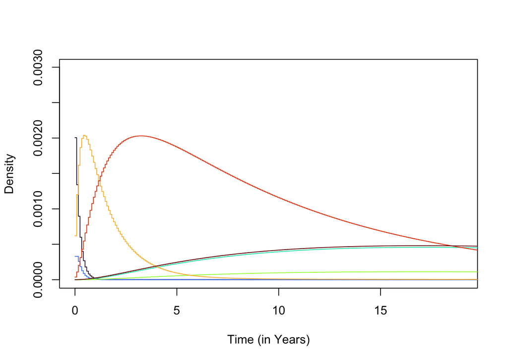

```r
plotGarkiVars(out_box, Amax=19)
```

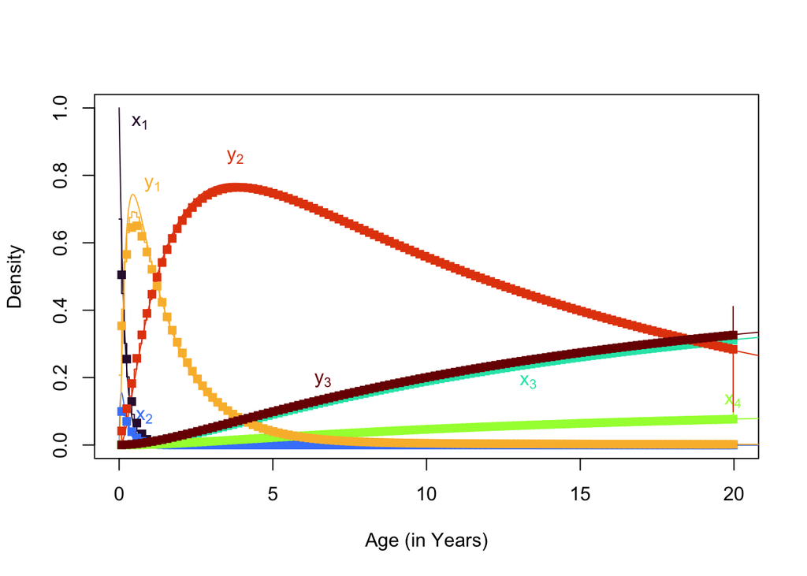

```r
plotGarkiVars(out_age, Amax=20, norm=TRUE)
plotGarkiVars(out_box, Amax=20, norm=TRUE, newplot=FALSE)
pointsGarkiVars(out_box2, norm=TRUE, ppch=15)
```

### Uneven Boxcar

#### -

```r
UnevenAgingMatrix = function(D){
 N = length(D)
 Aging = diag(-1/c(D,1))
 Aging[N+1, N+1] = 0
 Aging[cbind(1+1:N, 1:N)] = 1/D
 return(Aging)
}
```

#### Wrapper

We can use the same derivatives, but we change the wrapper to pass the transfer matrix for uneven aging:

```r
unevenBoxcarSteady_Garki = function(foi, ell, params=makePar_Garki()){
 params$foi = foi
 Dn = length(ell)
 N = Dn+1
 params$Dn = Dn
 params$N = N
 params$D = ell
 params$births = c(1, rep(0,Dn))
 y0 = rep(.1, 7*N)
 Aging = UnevenAgingMatrix(ell)
 out <- steady(y0,NULL,Garki_dXdt_boxcar, params, Aging=Aging)$y
 out <- de2vars(out, params)
 params$age_mesh = ell
 out$min_age = c(0,cumsum(ell))
 out$max_age = c(cumsum(ell), 36500)
 fullOutput = list(steady=out, par=params)
 class(fullOutput) <- "boxcar"
 return(fullOutput)
}
```

```r
unevenBoxcarSteady_Garki(6/365, DD)->out_uneven
```

#### Mesh

```r
DD = c(rep(365/12,12), rep(365/2, 18), rep(730, 5), rep(3650, 6))
cumsum(DD)-> ages
```

```r
ages[1:11]/30
```

```
##  [1]  1.013889  2.027778  3.041667  4.055556  5.069444  6.083333  7.097222
##  [8]  8.111111  9.125000 10.138889 11.152778
```

The remaining breakpoints are defined by year:

```r
ages[-c(1:11)]/365
```

```
##  [1]  1.0  1.5  2.0  2.5  3.0  3.5  4.0  4.5  5.0  5.5  6.0  6.5  7.0  7.5  8.0
## [16]  8.5  9.0  9.5 10.0 12.0 14.0 16.0 18.0 20.0 30.0 40.0 50.0 60.0 70.0 80.0
```

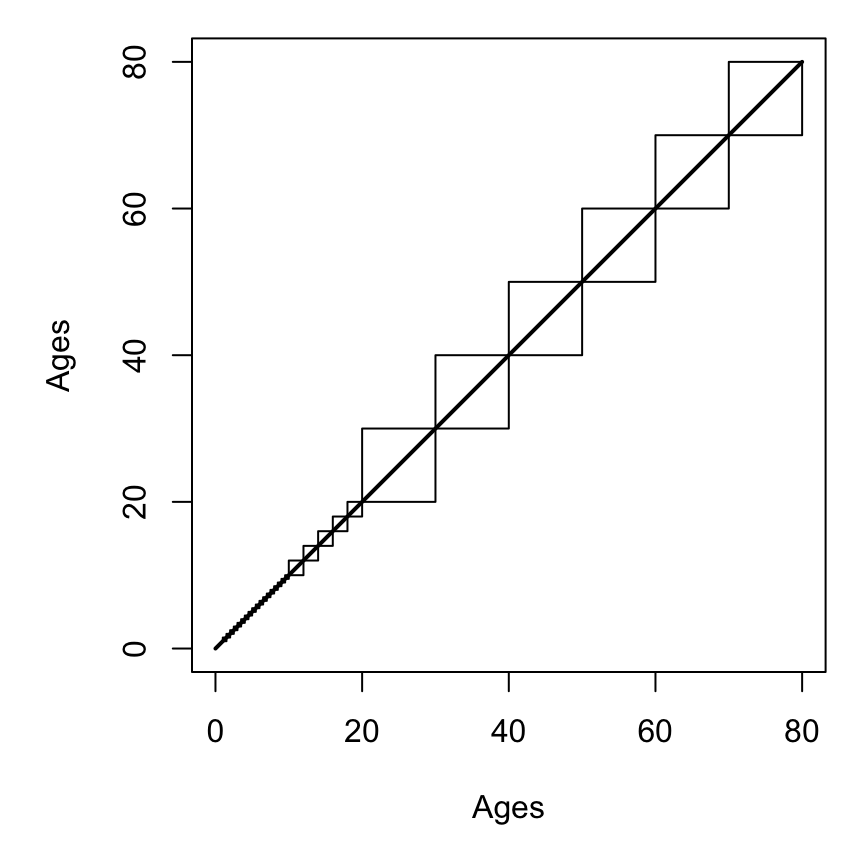

```r
par(mar = c(5,5,1,1))
plot(c(0, ages)/365, c(0,ages)/365, type = "l", xlab = "Ages", ylab = "Ages", lwd=2)
lines(cumsum(DD)/365, cumsum(DD)/365, type = "S")
lines(cumsum(DD)/365, cumsum(DD)/365, type = "s")
```

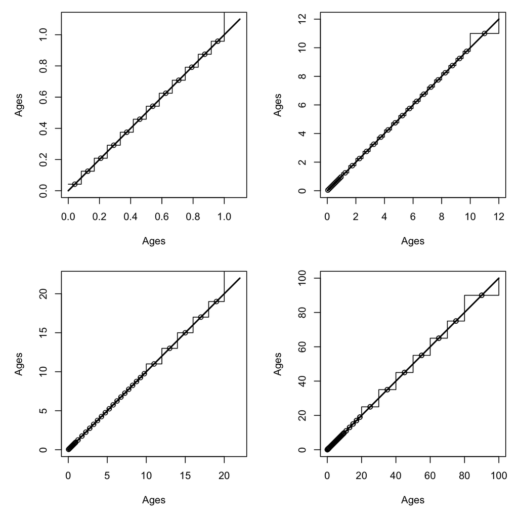

```r
par(mar = c(5,5,1,1), mfrow = c(2,2))
mid = (c(0, ages) + c(ages, 36500))/2
plot(c(0, 1.1), c(0,1.1), type = "l", xlab = "Ages", ylab = "Ages", lwd=2)
lines(c(0,ages)/365, mid/365, type = "s")
points(mid/365, mid/365)
plot(c(0, 12), c(0,12), type = "l", xlab = "Ages", ylab = "Ages", lwd=2)
lines(c(0,ages)/365, mid/365, type = "s")
points(mid/365, mid/365)
plot(c(0, 22), c(0,22), type = "l", xlab = "Ages", ylab = "Ages", lwd=2)
lines(c(0,ages)/365, mid/365, type = "s")
points(mid/365, mid/365)
plot(c(0, 100), c(0,100), type = "l", xlab = "Ages", ylab = "Ages", lwd=2)
lines(c(0,ages, 36500)/365, c(mid/365,100), type = "s")
points(mid/365, mid/365)

points(mid/365, mid/365)
```

#### Graphs

```r
unevenBoxcarSteady_Garki(6/365,DD) -> out_uneven
```

The raw plots look jagged because the variables are densities.

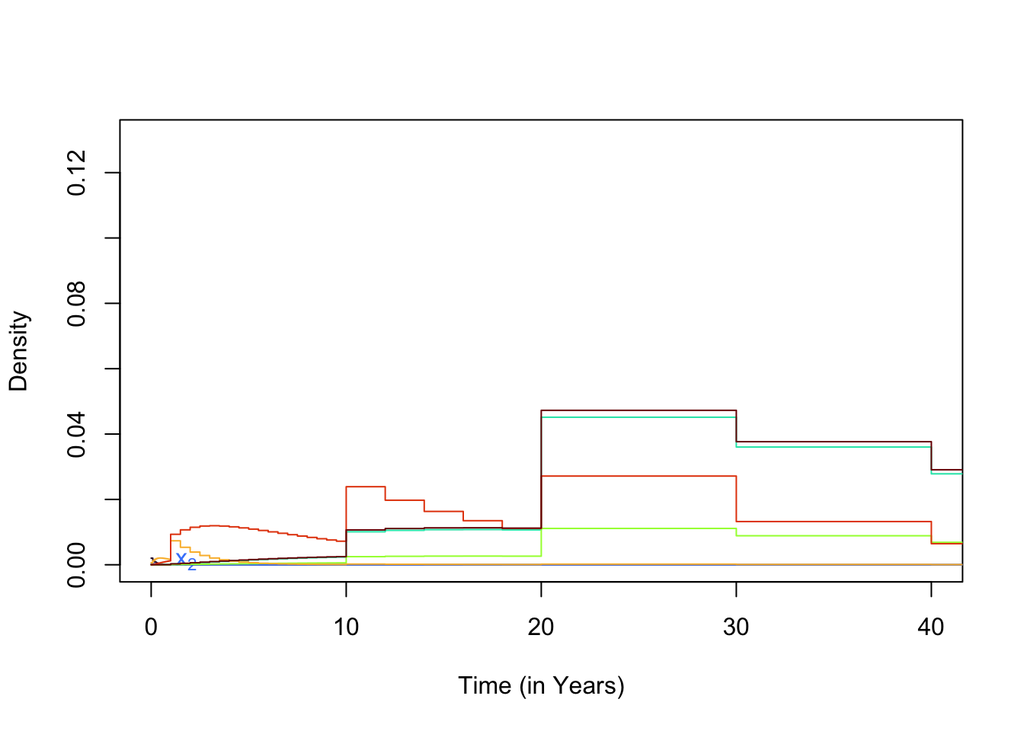

```r
plotGarkiVars(out_uneven, Amax=40)
```

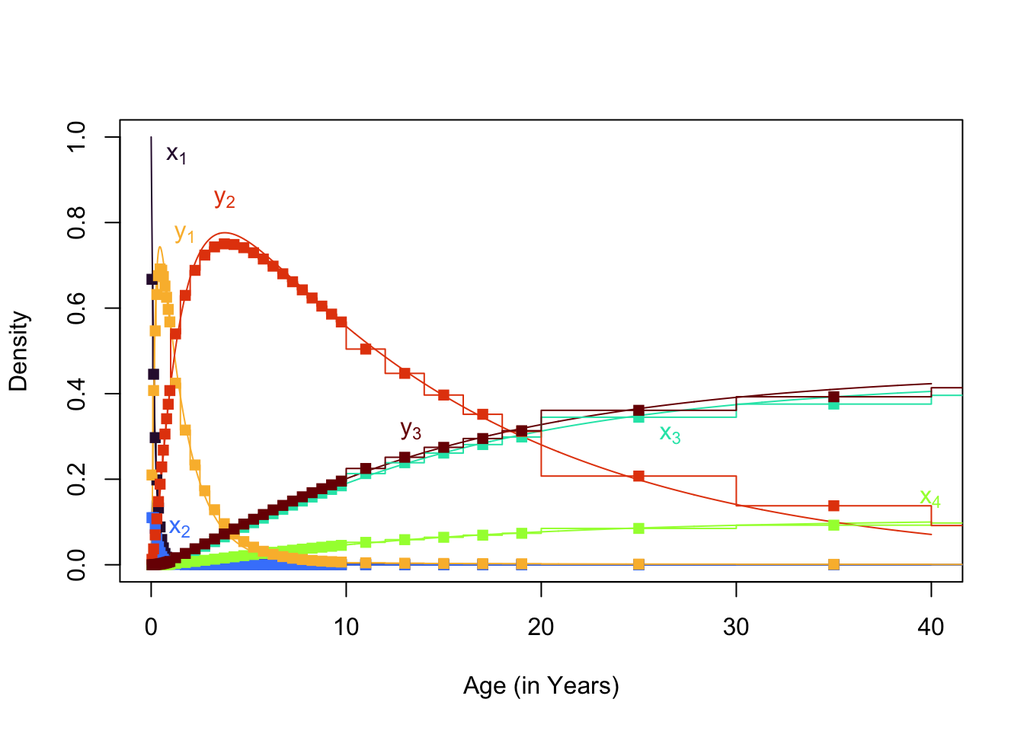

```r
plotGarkiVars(out_age, Amax=40, norm=TRUE)
plotGarkiVars(out_uneven, Amax=40, norm=TRUE, newplot=FALSE)
pointsGarkiVars(out_uneven, norm=TRUE)
```

### Lagged Age

This implements the lagged age model. I developed it hoping it would be both accurate and fast. It’s slow, so it probably works, but we’ll never use it.

```r
Garki_dXda_lagage = function(t, y, params){with(params, {
  x1 = y[x1_ix]; x2 = y[x2_ix]; x3 = y[x3_ix]; x4 = y[x4_ix]
  y1 = y[y1_ix]; y2 = y[y2_ix]; y3 = y[y3_ix];
  X = x1+x2+x3+x4+y1+y2+y3

  # get lagged values
  x1_lag = x1_lag0; x2_lag = x2_lag0; x3_lag = x3_lag0; x4_lag = x4_lag0
  y1_lag = y1_lag0; y2_lag = y2_lag0; y3_lag = y3_lag0
  ix = which(t>ell)
  if(length(ix)>0){
    x1_lag[ix] = lagvalue(t-ell[ix], x1_ix[ix])
    x2_lag[ix] = lagvalue(t-ell[ix], x2_ix[ix])
    x3_lag[ix] = lagvalue(t-ell[ix], x3_ix[ix])
    x4_lag[ix] = lagvalue(t-ell[ix], x4_ix[ix])
    y1_lag[ix] = lagvalue(t-ell[ix], y1_ix[ix])
    y2_lag[ix] = lagvalue(t-ell[ix], y2_ix[ix])
    y3_lag[ix] = lagvalue(t-ell[ix], y3_ix[ix])
  }
  X_lag = (x1_lag+x2_lag+x3_lag+x4_lag+y1_lag+y2_lag+y3_lag)*exp(-c(mu*ell,0))

  aging =  diag(-c(X_lag[-N], 0))
  aging[ldix] = X_lag[-N]
  aging = aging %*% diag(1/X)

  h = foi*foiSeason(t, params)*foiAge(t, params)
  R1 = h/(exp(h/r1) - 1)
  R2 = h/(exp(h/r2) - 1)
  dx1 = - h*x1 + R1*y2 - mu*x1 + aging %*% x1
  dx2 = h*x1 - nu*x2 - mu*x2 + aging %*% x2
  dy1 = nu*x2 - alpha1*y1 - mu*y1 + aging %*% y1
  dy2 = alpha1*y1 - R1*y2 - alpha2*y2 - mu*y2 + aging %*% y2
  dy3 = alpha2*y2 + nu*x4 - R2*y3 - mu*y3 + aging %*% y3
  dx3 = R2*y3 - h*x3 - mu*x3 + aging %*% x3
  dx4 = h*x3 - nu*x4 - mu*x4 + aging %*% x4

  dx1[1] = dx1[1] + B

  list(c(dx1, dx2, dy1, dy2, dy3, dx3, dx4))
})}
```

```r
Garki_dXda_lagage1 = function(t, y, params){with(params, {
  x1 = y[x1_ix]; x2 = y[x2_ix]; x3 = y[x3_ix]; x4 = y[x4_ix]
  y1 = y[y1_ix]; y2 = y[y2_ix]; y3 = y[y3_ix];
  X = x1+x2+x3+x4+y1+y2+y3

  X_lag = B*exp(-mu*ell_up)
  aging = diag(-c(X_lag, 0))
  aging[ldix] = X_lag
  aging = aging %*% diag(1/X)

  h = foi*foiSeason(t, params)*foiAge(t, params)
  R1 = h/(exp(h/r1) - 1)
  R2 = h/(exp(h/r2) - 1)

  dx1 = births*delta(t, params) - h*x1 + R1*y2 - mu*x1 + aging %*% x1
  dx2 = h*x1 - nu*x2 - mu*x2 + aging %*% x2
  dy1 = nu*x2 - alpha1*y1 - mu*y1 + aging %*% y1
  dy2 = alpha1*y1 - R1*y2 - alpha2*y2 - mu*y2 + aging %*% y2
  dy3 = alpha2*y2 + nu*x4 - R2*y3 - mu*y3 + aging %*% y3
  dx3 = R2*y3 - h*x3 - mu*x3 + aging %*% x3
  dx4 = h*x3 - nu*x4 - mu*x4 + aging %*% x4

  list(c(dx1, dx2, dy1, dy2, dy3, dx3, dx4))
})}
```

```r
modPar_Garki_lagage = function(foi, ell, params, ySteady){
 params$foi = foi
 Dn = length(ell)
 params$ldix = cbind(1+1:Dn, 1:Dn)
 params$ell = ell
 params$ell_up = cumsum(ell)

 params$births = c(1, rep(0, Dn))

 params$x1_lag0 = ySteady$x1
 params$x2_lag0 = ySteady$x2
 params$x3_lag0 = ySteady$x3
 params$x4_lag0 = ySteady$x4
 params$y1_lag0 = ySteady$y1
 params$y2_lag0 = ySteady$y2
 params$y3_lag0 = ySteady$y3

 N = Dn+1
 params$x1_ix = 1:N
 params$x2_ix = 1:N + N
 params$x3_ix = 1:N + N*5
 params$x4_ix = 1:N + N*6
 params$y1_ix = 1:N + N*2
 params$y2_ix = 1:N + N*3
 params$y3_ix = 1:N + N*4
 params$N=N
 params$age = c(cumsum(ell) - ell/2, (sum(ell) + 100*365)/2)
 return(params)
}
```

```r
laggedAgeSolve_Garki = function(foi, ell, params=makePar_Garki(), Tmax=20, ySteady=NULL, kluge=FALSE){
 if(is.null(ySteady)) ySteady = unevenBoxcarSteady_Garki(foi, ell, params)
 params = modPar_Garki_lagage(foi, ell, params, ySteady)
 y0 = with(ySteady, c(x1, x2, y1, y2, y3, x3, x4))
 tt = seq(0, Tmax*365, by=20)

 if(kluge==TRUE){
   out <- dede(y0, tt, Garki_dXda_lagage1,  params)
   tail2vars(out, params) -> out1
   out1$min_age = c(0,cumsum(ell))
   out1$max_age = c(cumsum(ell), 36500)
   fullOutput = list(steady=out1, ts=out)
 } else {
   #out <- dede(y0, tt, Garki_dXda_lagage,  params)
   #tail2vars(out, params) -> out1
   out <- steady(y0, NULL, Garki_dXda_lagage,  params)
   de2vars(out, params)->out1
   out1$min_age = c(0,cumsum(ell))
   out1$max_age = c(cumsum(ell), 36500)
   fullOutput = list(steady=out1)
 }
 params$age_mesh = ell
 fullOutput$par = params
 class(fullOutput) <- "boxcar"
 return(fullOutput)
}
```

```r
unevenBoxcarSteady_Garki(6/365, DD)$steady->infrom_uneven
laggedAgeSolve_Garki(6/365, DD, ySteady=infrom_uneven, kluge=TRUE)-> out_lagged
```

```r
plotGarkiVars(out_lagged)
```

[output not shown]

```r
plotGarkiVars(out_age, Amax=40)
plotGarkiVars(out_lagged, Amax=30, norm=TRUE, newplot = FALSE)
pointsGarkiVars(out_lagged, norm=TRUE)
```

[output not shown]

```r
with(out_lagged, plot(age/365, PR, type = "l"))
```

[output not shown]

## Compare

### Computational Speeds

```r
time1 = Sys.time()
unevenBoxcarSteady_Garki(6/365,DD) -> out_uneven
time2 = Sys.time()
time2-time1
```

```
## Time difference of 0.06137013 secs
```

### Accuracy

```r
par(mfrow = c(1,2))
plotCohort_Garki(out_age)
plotCohort_Garki(out_box$out)
```

[output not shown]

```r
with(out_age, plot(age/365, PR, type = "l", col = "darkred"))
with(out_box$out, lines(age/365, PR, col = "darkred", lty=2))
```

[output not shown]

```r
with(out_age,{
     plot(age, truePR, type ="l", col = "blue")
     lines(age, PR, col = "red")
})

with(out_uneven, {
     lines(age, truePR,  col = "blue", lty=2)
     lines(age, PR, col = "red", lty=2)
})
```

[output not shown]

## References

1.

Dietz K, Molineaux L, Thomas A. A malaria model tested in the African savannah. Bull Wld Hlth Org. 1974;50: 347–357. Available: http://www.ncbi.nlm.nih.gov/entrez/query.fcgi?cmd=Retrieve&db=PubMed&dopt=Citation&list_uids=4613512

2.

Wu SL, Henry JM, Citron DT, Mbabazi Ssebuliba D, Nakakawa Nsumba J, Sánchez C. HM, et al. Spatial Dynamics of Malaria Transmission. 2022. Available: http://medrxiv.org/content/early/2022/11/15/2022.11.07.22282044.abstract

3.

Fletcher CAJ. Computational Galerkin Methods. In: Fletcher CAJ, editor. Computational Galerkin Methods. Berlin, Heidelberg: Springer; 1984. pp. 72–85. doi:10.1007/978-3-642-85949-6_2